# ANOVA and other statistics methods

Ph D. Valentin Pérez Hernández & Ph D. Mario Hernández-Guzmán

8/10/2022

## Configurando opciones de R y cargando las librerías a emplear en los análisis

```r
# Configuraciones generales
options(digits = 3)

# librerías a emplear en la sesión
library(ggplot2)  # gráficos
library(car)      # pruebas estadísticas
library(nortest)  # pruebas estadísticas
library(FSA)      # test no paramétricos
```

## Referencias: Leer los tutoriales!

https://rpubs.com/Joaquin_AR/219148

https://rcompanion.org/rcompanion/d_06.html

## CARGANDO DATOS

Los datos pueden ser cargados de dos formas: desde tu disco duro, y desde la nube de GoogleDrive ([ver fuente](https://stackoverflow.com/questions/33135060/read-csv-file-hosted-on-google-drive)). La segunda opción necesita acceso a internet, y conocer el “id” del archivo a descargar.

```r
# Cargar el archivo desde tu disco duro. tienes que conocer la ubicación exacta del archivo.
#data <- read.csv("C:/Users/Vale/Desktop/fisicoquimicos_mimosa.csv")

# Desde Google Drive:
data <- read.csv(sprintf("https://docs.google.com/uc?id=%s&export=download", "1rZm0RKOrMsRpFOl6Djlyk5bRwrNgbyEy"))
dim(data)
```

```
## [1] 54 10
```

```r
str(data)
```

```
## 'data.frame':    54 obs. of  10 variables:
##  $ Treatment  : chr  "C0_1" "C0_1" "C0_1" "C1_1" ...
##  $ Tratamiento: chr  "C0" "C0" "C0" "C1" ...
##  $ Day        : int  7 7 7 7 7 7 7 7 7 14 ...
##  $ Treat_day  : chr  "C0_7" "C0_7" "C0_7" "C1_7" ...
##  $ Nitrogen   : num  0.203 0.214 0.197 0.203 0.197 0.191 0.197 0.194 0.203 0.205 ...
##  $ g.N.Kg.s   : num  2.03 2.14 1.97 2.03 1.97 1.91 1.97 1.94 2.03 2.05 ...
##  $ CE         : num  0.25 0.23 0.23 0.31 0.27 0.35 0.34 0.35 0.33 0.28 ...
##  $ pH         : num  5.79 6.4 5.62 6.24 6.06 5.96 5.71 5.31 5.93 5.55 ...
##  $ COT        : num  12.3 23 19.1 22 14 ...
##  $ CRA        : num  496 519 451 487 492 ...
```

```r
head(data)
```

```
##   Treatment Tratamiento Day Treat_day Nitrogen g.N.Kg.s   CE   pH  COT CRA
## 1      C0_1          C0   7      C0_7    0.203     2.03 0.25 5.79 12.3 496
## 2      C0_1          C0   7      C0_7    0.214     2.14 0.23 6.40 23.0 519
## 3      C0_1          C0   7      C0_7    0.197     1.97 0.23 5.62 19.1 451
## 4      C1_1          C1   7      C1_7    0.203     2.03 0.31 6.24 22.0 487
## 5      C1_1          C1   7      C1_7    0.197     1.97 0.27 6.06 14.0 492
## 6      C1_1          C1   7      C1_7    0.191     1.91 0.35 5.96 15.1 378
```

```r
tail(data)
```

```
##    Treatment Tratamiento Day Treat_day Nitrogen g.N.Kg.s   CE   pH  COT CRA
## 49      C1_6          C1  70     C1_70    0.194     1.94 0.29 5.41 12.6 572
## 50      C1_6          C1  70     C1_70    0.186     1.86 0.40 5.93 17.4 638
## 51      C1_6          C1  70     C1_70    0.208     2.08 0.37 5.89 22.5 637
## 52      C2_6          C2  70     C2_70    0.208     2.08 0.41 6.29 22.8 516
## 53      C2_6          C2  70     C2_70    0.189     1.89 0.41 5.96 17.5 535
## 54      C2_6          C2  70     C2_70    0.208     2.08 0.26 5.82 22.9 554
```

## EVALUAR DE MANERA VISUAL EL COMPORTAMIENTO DE LOS DATOS

GRÁFICA: GRÁFICO DE CAJAS Y BIGOTES PARA OBSERVAR LA DISTRIBUCIÓN DE LOS DATOS POR TRATAMIENTO

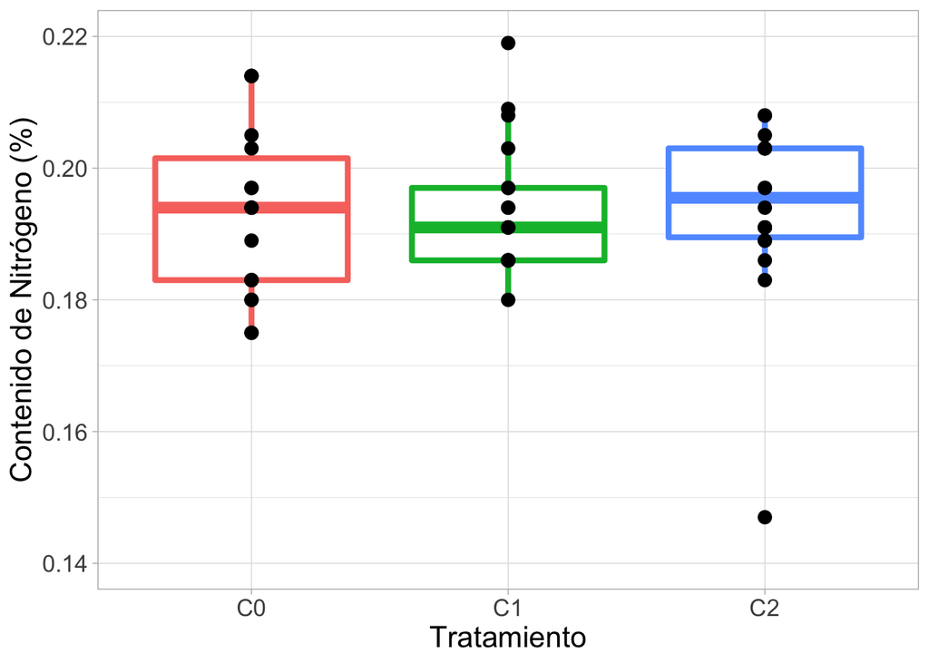

```r
ggplot2::ggplot(data = data, aes(x = Tratamiento, y = Nitrogen, colour = Tratamiento)) +
        geom_boxplot(size = 1.5) +
        geom_point(size = 3, color = "black") +
        xlab ("Tratamiento") +
        scale_y_continuous(name = "Contenido de Nitrógeno (%)",
                           breaks = seq(from = 0.14, to = 0.22, by = 0.02),
                           limits=c(0.14,0.22)) +
        theme_light() +
        theme(legend.position = "none",
              text = element_text(size = 16, colour = "black"))
```

## ANALISIS DE VARIANZA: *ANOVA*

La técnica de análisis de varianza (ANOVA) también conocida como análisis factorial y desarrollada por Fisher en 1930, constituye la herramienta básica para el estudio del efecto de uno o más factores (cada uno con dos o más niveles) sobre la media de una variable continua.

El funcionamiento básico de un ANOVA consiste en calcular la media de cada uno de los grupos para a continuación comparar la varianza de estas medias (varianza explicada por la variable grupo, intervarianza) frente a la varianza promedio dentro de los grupos (la no explicada por la variable grupo, intravarianza).

Bajo la hipótesis nula de que las observaciones de los distintos grupos proceden todas la misma población (tienen la misma media y varianza):

*H0* : *No hay diferencias entre las medias de los diferentes grupos*: μ1 = μ2…= μk.

*H0* : Al menos un par de medias son significativamente distintas la una de la otra.

```r
nitrogen_aov <- aov (Nitrogen ~ Tratamiento, data=data)

summary (nitrogen_aov)
```

```
##             Df  Sum Sq  Mean Sq F value Pr(>F)
## Tratamiento  2 0.00001 6.40e-06    0.04   0.96
## Residuals   51 0.00793 1.55e-04
```

En este caso el ANOVA no ha resultado significativo por lo que no tiene sentido realizar comparaciones dos a dos. Sin embargo con fines didácticos se muestra como se harían.

## POST-HOC

Si un Análisis de Varianza resulta significativo, implica que al menos dos de las medias comparadas son significativamente distintas entre sí, pero no se indica cuáles. Para identificarlas hay que comparar dos a dos las medias de todos los grupos introducidos en el análisis mediante un t-test u otro test que compare 2 grupos, ha esto se le conoce como análisis post-hoc.

El método de Tukey se utiliza en ANOVA para crear intervalos de confianza para todas las diferencias en parejas entre las medias de los niveles de los factores mientras controla la tasa de error por familia en un nivel especificado.

```r
TukeyHSD(nitrogen_aov, conf.level = 0.95)
```

```
##   Tukey multiple comparisons of means
##     95% family-wise confidence level
##
## Fit: aov(formula = Nitrogen ~ Tratamiento, data = data)
##
## $Tratamiento
##            diff      lwr     upr p adj
## C1-C0  0.001167 -0.00886 0.01120 0.958
## C2-C0  0.000778 -0.00925 0.01081 0.981
## C2-C1 -0.000389 -0.01042 0.00964 0.995
```

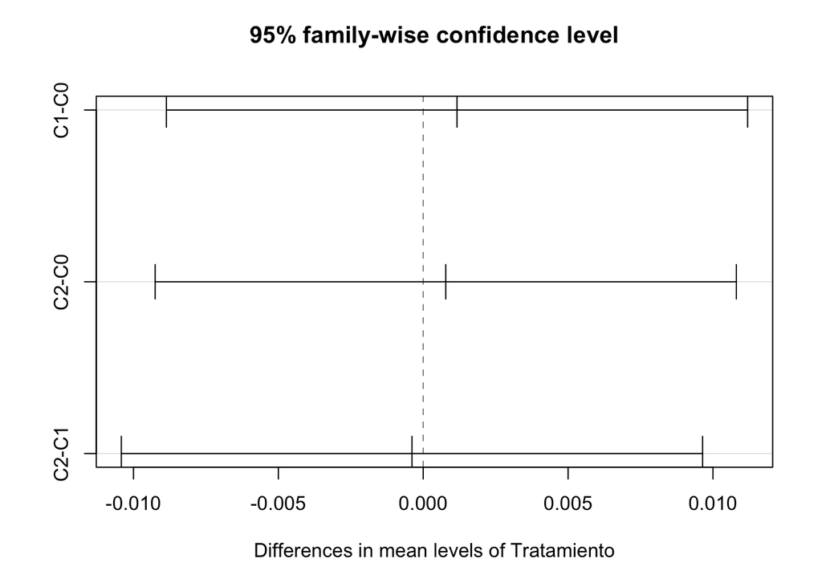

```r
plot(TukeyHSD(nitrogen_aov))
```

# NON-PARAMETRIC ANALYSIS

El test de Kruskal-Wallis, también conocido como test H, es la alternativa no paramétrica al test ANOVA de una vía para datos no pareados. A diferencia del ANOVA en el que se comparan medias, el test de Kruskal-Wallis contrasta si las diferentes muestras están equidistribuidas y que por lo tanto pertenecen a una misma distribución (población).

#### HIPOTESIS A EVALUAR

*H0* : todas las muestras provienen de la misma población (distribución).

*H1*: Al menos una muestra proviene de una población con una distribución distinta.

```r
Nitrogen_KW <- kruskal.test(Nitrogen ~ Tratamiento, data = data)

Nitrogen_KW
```

```
##
##  Kruskal-Wallis rank sum test
##
## data:  Nitrogen by Tratamiento
## Kruskal-Wallis chi-squared = 0.7, df = 2, p-value = 0.7
```

#### POST-HOC

Al igual que ocurre con un ANOVA, si el test de Kruskal-Wallis es significativo, implica que al menos dos grupos de entre los comparados son significativamente diferentes, pero no indica cuales. Para saberlo es necesario compararlos todos entre ellos.

## DUNN TEST

If the Kruskal–Wallis test is significant, a post-hoc analysis can be performed to determine which levels of the independent variable differ from each other level. Probably the most popular test for this is the Dunn test, which is performed with the dunnTest function in the FSA package.

```r
test_dunn <- dunnTest(Nitrogen ~ Tratamiento, data = data, method="bh")
test_dunn
```

```
## Dunn (1964) Kruskal-Wallis multiple comparison
```

```
##   p-values adjusted with the Benjamini-Hochberg method.
```

[output not shown]

Dunn’s Test performs pairwise comparisons between each independent group and tells you which groups are statistically significantly different at some level of α.